# HarvardX PH125.9x - CYO Project - Credit Card Fraud

David Mc Manus

9/13/2022

# intro

## Aim

Similarly to the IEEE-CIS Fraud Detection [2] competition in 2019, this project will evaluate detection systems based on their ROC AUC scores.

The detection systems will include GLM, Decision Trees, Random Forrest,K Nearest Neighbours, and Google’s Keras methods.

## Loading Packages and Libraries

Check if the required packages are installed, and install any missing ones. ### Tensorflow/Keras need to install in a particular way “https://tensorflow.rstudio.com/install/” different way https://cran.r-project.org/web/packages/keras/vignettes/index.html

```r
if(!require(keras))install.packages("keras")
library(keras)
install_keras(envname = "r-reticulate")
```

```
##
## Installation complete.
```

```r
# Installing Required Packages
if(!require(jsonlite))install.packages("jsonlite", repos="http://cran.us.r-project.org")
if(!require(tidyverse))install.packages("tidyverse", repos = "http://cran.us.r-project.org")
if(!require(tidyr))install.packages('tidyr', repos = "http://cran.us.r-project.org")
if(!require(dplyr))install.packages('dplyr', repos = "http://cran.us.r-project.org")
if(!require(kableExtra))install.packages("kableExtra", repos = "http://cran.us.r-project.org")
if(!require(ggplot2))install.packages('ggplot2', repos = "http://cran.us.r-project.org")
if(!require(caret))install.packages('caret', repos = "http://cran.us.r-project.org")
if(!require(ROSE))install.packages("ROSE", repos = "http://cran.us.r-project.org")
if(!require(pROC))install.packages('pRoc', repos = "http://cran.us.r-project.org")
if(!require(ranger))install.packages('ranger', repos = "http://cran.us.r-project.org")
if(!require(recipes))install.packages('recipes', repos = "http://cran.us.r-project.org")

#load other packages
library("jsonlite")
library("tidyverse")
library("tidyr")
library("dplyr")
library("kableExtra")
library("ggplot2")
library("caret")
library("ROSE")
library("pROC")
library("ranger")
library("recipes")

library("keras")
library("tensorflow")
```

```r
set.seed(1, sample.kind = "Rounding")
set_random_seed(1)
```

```
## Loaded Tensorflow version 2.9.2
```

# Dataset

First published by Pozzolo et al. [3], the data set contains over 280,000 transaction made by European card holders in September 2013. The data has undergone PCA transformation, leaving only numeric variables, while due to confidentiality issues, no background information or original features of the data is available. Each entry contains 31 features, V1 through V28, as well as three untouched by the PCA transformation: Time (seconds elapsed between each transaction and the first in the dataset), Amount, and Class (where 1 represents a case of fraud, and a 0 for legitimate transaction). [4] Of the 284, 807 transactions, only 492 are classed as fraud, accounting for 0.172% of the dataset. This extreme imbalance will need to be addressed, as severely imbalanced datasets can cause serious issues, up to and including algorithms ignoring the minority class entirely. [5]

The dataset can be found [here](https://datahub.io/machine-learning/creditcard).

## Analysing the Data

### Dataset Structure

```r
#check sturcture of dataset

head(data)%>%
  kbl(caption = "head of Dataset") %>%
  kable_styling(latex_options = c("striped"))%>%
  scroll_box(height = "100%", width = "100%", fixed_thead = TRUE)
```

head of Dataset

| Time | V1 | V2 | V3 | V4 | V5 | V6 | V7 | V8 | V9 | V10 | V11 | V12 | V13 | V14 | V15 | V16 | V17 | V18 | V19 | V20 | V21 | V22 | V23 | V24 | V25 | V26 | V27 | V28 | Amount | … |
| --- | --- | --- | --- | --- | --- | --- | --- | --- | --- | --- | --- | --- | --- | --- | --- | --- | --- | --- | --- | --- | --- | --- | --- | --- | --- | --- | --- | --- | --- | --- |
| 0 | -1.3598071 | -0.0727812 | 2.5363467 | 1.3781552 | -0.3383208 | 0.4623878 | 0.2395986 | 0.0986979 | 0.3637870 | 0.0907942 | -0.5515995 | -0.6178009 | -0.9913898 | -0.3111694 | 1.4681770 | -0.4704005 | 0.2079712 | 0.0257906 | 0.4039930 | 0.2514121 | -0.0183068 | 0.2778376 | -0.1104739 | 0.0669281 | 0.1285394 | -0.1891148 | 0.1335584 | -0.0210531 | 149.62 | … |
| 0 | 1.1918571 | 0.2661507 | 0.1664801 | 0.4481541 | 0.0600176 | -0.0823608 | -0.0788030 | 0.0851017 | -0.2554251 | -0.1669744 | 1.6127267 | 1.0652353 | 0.4890950 | -0.1437723 | 0.6355581 | 0.4639170 | -0.1148047 | -0.1833613 | -0.1457830 | -0.0690831 | -0.2257752 | -0.6386720 | 0.1012880 | -0.3398465 | 0.1671704 | 0.1258945 | -0.0089831 | 0.0147242 | 2.69 | … |
| 1 | -1.3583541 | -1.3401631 | 1.7732093 | 0.3797796 | -0.5031981 | 1.8004994 | 0.7914610 | 0.2476758 | -1.5146543 | 0.2076429 | 0.6245015 | 0.0660837 | 0.7172927 | -0.1659459 | 2.3458649 | -2.8900832 | 1.1099694 | -0.1213593 | -2.2618571 | 0.5249797 | 0.2479982 | 0.7716794 | 0.9094123 | -0.6892810 | -0.3276418 | -0.1390966 | -0.0553528 | -0.0597518 | 378.66 | … |
| 1 | -0.9662717 | -0.1852260 | 1.7929933 | -0.8632913 | -0.0103089 | 1.2472032 | 0.2376089 | 0.3774359 | -1.3870241 | -0.0549519 | -0.2264873 | 0.1782282 | 0.5077569 | -0.2879237 | -0.6314181 | -1.0596472 | -0.6840928 | 1.9657750 | -1.2326220 | -0.2080378 | -0.1083005 | 0.0052736 | -0.1903205 | -1.1755753 | 0.6473760 | -0.2219288 | 0.0627228 | 0.0614576 | 123.50 | … |
| 2 | -1.1582331 | 0.8777368 | 1.5487178 | 0.4030339 | -0.4071934 | 0.0959215 | 0.5929407 | -0.2705327 | 0.8177393 | 0.7530744 | -0.8228429 | 0.5381956 | 1.3458516 | -1.1196698 | 0.1751211 | -0.4514492 | -0.2370332 | -0.0381948 | 0.8034869 | 0.4085424 | -0.0094307 | 0.7982785 | -0.1374581 | 0.1412670 | -0.2060096 | 0.5022922 | 0.2194222 | 0.2151531 | 69.99 | … |
| 2 | -0.4259659 | 0.9605230 | 1.1411093 | -0.1682521 | 0.4209869 | -0.0297276 | 0.4762009 | 0.2603143 | -0.5686714 | -0.3714072 | 1.3412620 | 0.3598938 | -0.3580907 | -0.1371337 | 0.5176168 | 0.4017259 | -0.0581328 | 0.0686531 | -0.0331938 | 0.0849677 | -0.2082535 | -0.5598248 | -0.0263977 | -0.3714266 | -0.2327938 | 0.1059148 | 0.2538442 | 0.0810803 | 3.67 | … |

```r
summary(data)%>%
  kbl(caption = "Summary of Dataset") %>%
  kable_styling(latex_options = c("striped"))%>%
  scroll_box(height = "100%", width = "100%", fixed_thead = TRUE)
```

Summary of Dataset

|  | Time | V1 | V2 | V3 | V4 | V5 | V6 | V7 | V8 | V9 | V10 | V11 | V12 | V13 | V14 | V15 | V16 | V17 | V18 | V19 | V20 | V21 | V22 | V23 | V24 | V25 | V26 | V27 | V28 | … |
| --- | --- | --- | --- | --- | --- | --- | --- | --- | --- | --- | --- | --- | --- | --- | --- | --- | --- | --- | --- | --- | --- | --- | --- | --- | --- | --- | --- | --- | --- | --- |
|  | Min. : 0 | Min. :-56.40751 | Min. :-72.71573 | Min. :-48.3256 | Min. :-5.68317 | Min. :-113.74331 | Min. :-26.1605 | Min. :-43.5572 | Min. :-73.21672 | Min. :-13.43407 | Min. :-24.58826 | Min. :-4.79747 | Min. :-18.6837 | Min. :-5.79188 | Min. :-19.2143 | Min. :-4.49894 | Min. :-14.12985 | Min. :-25.16280 | Min. :-9.498746 | Min. :-7.213527 | Min. :-54.49772 | Min. :-34.83038 | Min. :-10.933144 | Min. :-44.80774 | Min. :-2.83663 | Min. :-10.29540 | Min. :-2.60455 | Min. :-22.565679 | Min. :-15.43008 | … |
|  | 1st Qu.: 54202 | 1st Qu.: -0.92037 | 1st Qu.: -0.59855 | 1st Qu.: -0.8904 | 1st Qu.:-0.84864 | 1st Qu.: -0.69160 | 1st Qu.: -0.7683 | 1st Qu.: -0.5541 | 1st Qu.: -0.20863 | 1st Qu.: -0.64310 | 1st Qu.: -0.53543 | 1st Qu.:-0.76249 | 1st Qu.: -0.4056 | 1st Qu.:-0.64854 | 1st Qu.: -0.4256 | 1st Qu.:-0.58288 | 1st Qu.: -0.46804 | 1st Qu.: -0.48375 | 1st Qu.:-0.498850 | 1st Qu.:-0.456299 | 1st Qu.: -0.21172 | 1st Qu.: -0.22839 | 1st Qu.: -0.542350 | 1st Qu.: -0.16185 | 1st Qu.:-0.35459 | 1st Qu.: -0.31715 | 1st Qu.:-0.32698 | 1st Qu.: -0.070840 | 1st Qu.: -0.05296 | … |
|  | Median : 84692 | Median : 0.01811 | Median : 0.06549 | Median : 0.1799 | Median :-0.01985 | Median : -0.05434 | Median : -0.2742 | Median : 0.0401 | Median : 0.02236 | Median : -0.05143 | Median : -0.09292 | Median :-0.03276 | Median : 0.1400 | Median :-0.01357 | Median : 0.0506 | Median : 0.04807 | Median : 0.06641 | Median : -0.06568 | Median :-0.003636 | Median : 0.003735 | Median : -0.06248 | Median : -0.02945 | Median : 0.006782 | Median : -0.01119 | Median : 0.04098 | Median : 0.01659 | Median :-0.05214 | Median : 0.001342 | Median : 0.01124 | … |
|  | Mean : 94814 | Mean : 0.00000 | Mean : 0.00000 | Mean : 0.0000 | Mean : 0.00000 | Mean : 0.00000 | Mean : 0.0000 | Mean : 0.0000 | Mean : 0.00000 | Mean : 0.00000 | Mean : 0.00000 | Mean : 0.00000 | Mean : 0.0000 | Mean : 0.00000 | Mean : 0.0000 | Mean : 0.00000 | Mean : 0.00000 | Mean : 0.00000 | Mean : 0.000000 | Mean : 0.000000 | Mean : 0.00000 | Mean : 0.00000 | Mean : 0.000000 | Mean : 0.00000 | Mean : 0.00000 | Mean : 0.00000 | Mean : 0.00000 | Mean : 0.000000 | Mean : 0.00000 | … |
|  | 3rd Qu.:139321 | 3rd Qu.: 1.31564 | 3rd Qu.: 0.80372 | 3rd Qu.: 1.0272 | 3rd Qu.: 0.74334 | 3rd Qu.: 0.61193 | 3rd Qu.: 0.3986 | 3rd Qu.: 0.5704 | 3rd Qu.: 0.32735 | 3rd Qu.: 0.59714 | 3rd Qu.: 0.45392 | 3rd Qu.: 0.73959 | 3rd Qu.: 0.6182 | 3rd Qu.: 0.66251 | 3rd Qu.: 0.4931 | 3rd Qu.: 0.64882 | 3rd Qu.: 0.52330 | 3rd Qu.: 0.39968 | 3rd Qu.: 0.500807 | 3rd Qu.: 0.458949 | 3rd Qu.: 0.13304 | 3rd Qu.: 0.18638 | 3rd Qu.: 0.528554 | 3rd Qu.: 0.14764 | 3rd Qu.: 0.43953 | 3rd Qu.: 0.35072 | 3rd Qu.: 0.24095 | 3rd Qu.: 0.091045 | 3rd Qu.: 0.07828 | … |
|  | Max. :172792 | Max. : 2.45493 | Max. : 22.05773 | Max. : 9.3826 | Max. :16.87534 | Max. : 34.80167 | Max. : 73.3016 | Max. :120.5895 | Max. : 20.00721 | Max. : 15.59500 | Max. : 23.74514 | Max. :12.01891 | Max. : 7.8484 | Max. : 7.12688 | Max. : 10.5268 | Max. : 8.87774 | Max. : 17.31511 | Max. : 9.25353 | Max. : 5.041069 | Max. : 5.591971 | Max. : 39.42090 | Max. : 27.20284 | Max. : 10.503090 | Max. : 22.52841 | Max. : 4.58455 | Max. : 7.51959 | Max. : 3.51735 | Max. : 31.612198 | Max. : 33.84781 | … |

```r
anyNA(data) %>%
  kbl(col.names = "Any NA's") %>%
  kable_styling(latex_options = c("striped"))
```

| Any NA’s |
| --- |
| FALSE |

### Renaming Levels

Before we start, for the sake of later ease, we should change the levels of class. To make our tables and graphs a bit easier to read, instead of 0 and 1, we will change them to “Good” and “Fraud”. At the same time, as we want to detect fraud, we can relevel them so our sensitivity and specificity scores, are accurate.

```r
data$Class <- as.factor(data$Class)
levels(data$Class)[levels(data$Class)=="'1'"]<- 'Fraud'
levels(data$Class)[levels(data$Class)=="'0'"]<- 'Good'

data$Class <- relevel(data$Class, "Fraud")
```

### Rate of Fraud

Lets look at the amount and percentage of fraud in the data set.

```r
table(data$Class) %>%
  kbl(caption = "Number of Real and Fraudulent Transactions") %>%
  kable_styling(latex_options = c("striped"))
```

Number of Real and Fraudulent Transactions

| Var1 | Freq |
| --- | --- |
| Fraud | 492 |
| Good | 284315 |

```r
prop.table(table(data$Class))%>%
  kbl(caption = "Frequency of Real and Fraudulent Transactions") %>%
  kable_styling(latex_options = c("striped"))
```

Frequency of Real and Fraudulent Transactions

| Var1 | Freq |
| --- | --- |
| Fraud | 0.0017275 |
| Good | 0.9982725 |

As we can see, the set is extremely unbalanced.

## Correlations

Before delving into the detection systems, it may be worthwhile to visualize the some of the features relationship to fraudulent and legitimate transactions. Apart from Class, the other two features we know are Time and Amount, so lets look at them first. For the sake of brevity, we will only look at a small sample of the remaining features. This sample will be chosen to best illustrate all of the features.

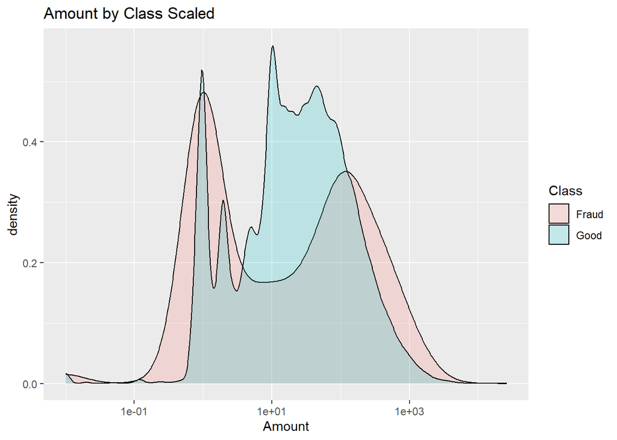

```r
#amount v Class
data %>%
  ggplot(aes(Amount, fill = Class)) +
  geom_density(alpha = 0.2)+
  scale_x_log10()+
  ggtitle("Amount by Class Scaled")
```

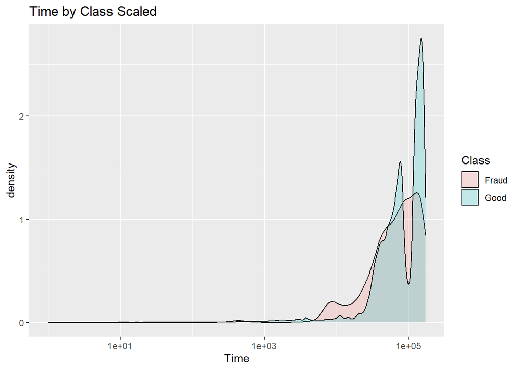

```r
#time v class
data %>%
  ggplot(aes(Time, fill = Class)) +
  geom_density(alpha = 0.2) +
  scale_x_log10()+
  ggtitle("Time by Class Scaled")
```

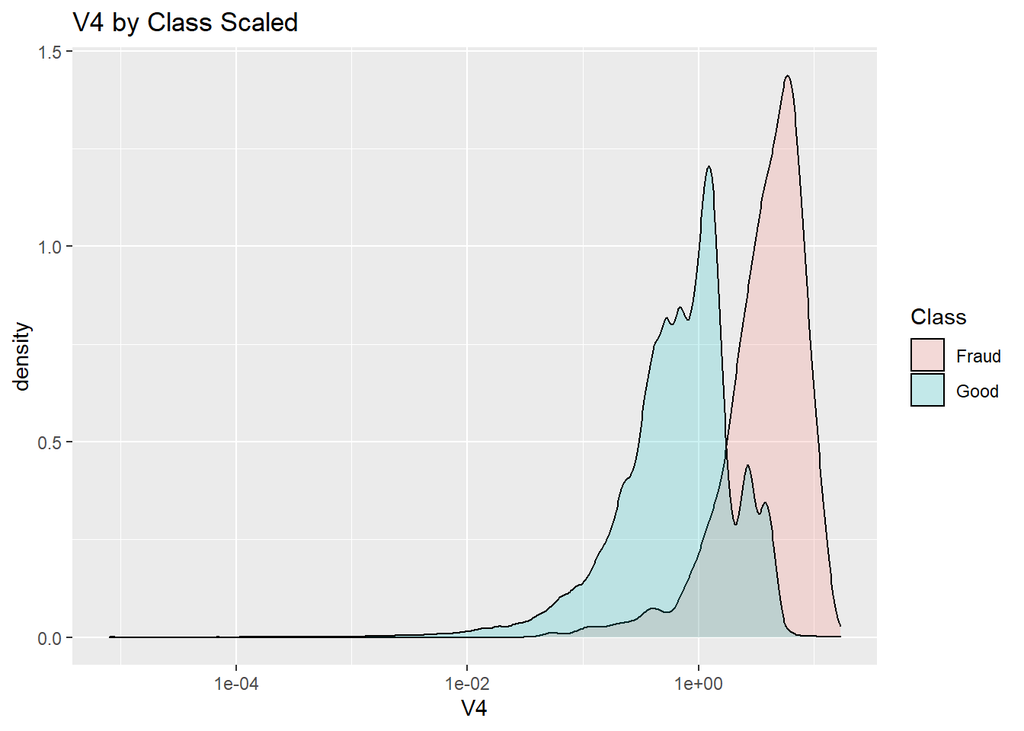

```r
#V4, V9, V11, V15 V Class
#V4
data %>%
  ggplot(aes(V4, fill = Class)) +
  geom_density(alpha = 0.2) +
  scale_x_log10()+
  ggtitle("V4 by Class Scaled")
```

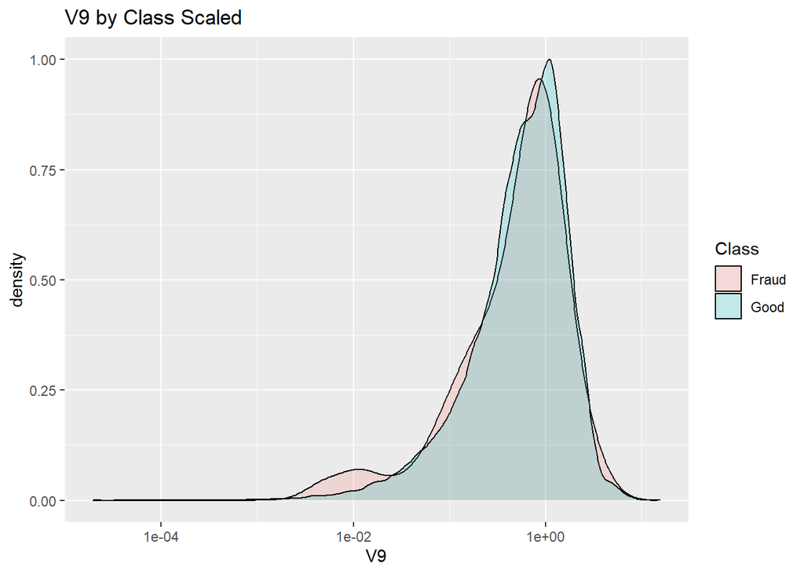

```r
#V9
data %>%
  ggplot(aes(V9, fill = Class)) +
  geom_density(alpha = 0.2) +
  scale_x_log10()+
  ggtitle("V9 by Class Scaled")
```

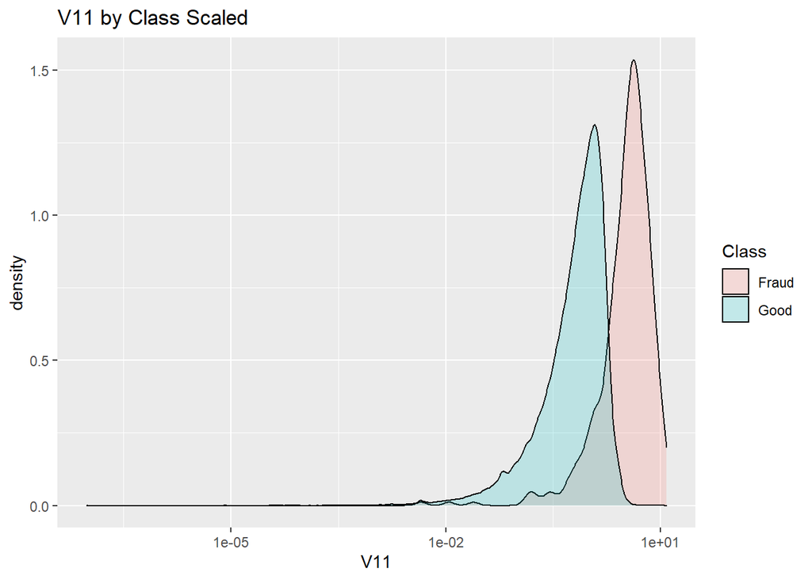

```r
#V11
data %>%
  ggplot(aes(V11, fill = Class)) +
  geom_density(alpha = 0.2) +
  scale_x_log10()+
  ggtitle("V11 by Class Scaled")
```

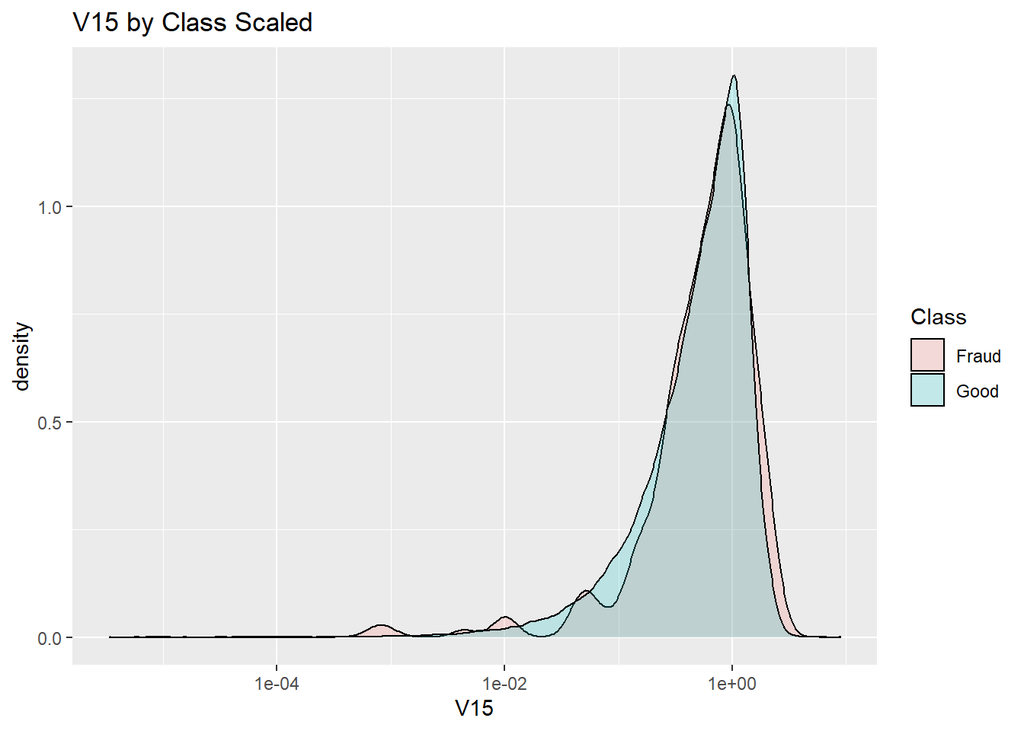

```r
#V15
data %>%
  ggplot(aes(V15, fill = Class)) +
  geom_density(alpha = 0.2) +
  scale_x_log10()+
  ggtitle("V15 by Class Scaled")
```

Where as V9 and V15 are almost perfectly matching, and V4 and V11 display a higher degree of distinction, all the remaining features fall in-between the two extremes. In all cases the overlap, although varying, is significant enough that any model based solely on these relationships would not result in an acceptable level of accuracy.

## Creating Validation, Test and Train sets

### Validation and Test sets

Before moving on to building and testing our models, there is an issue which needs to be addressed first. As mentioned before, the data set is extremely unbalanced, which can cause serious issue during training. However, in order to help preserve real world validity, both the validation and test sets will remain unbalanced. We will keep 20% of the entire data set for Validation, and 20% of the remaining entries for our test set.

```r
# Creating Validation, Train and Test sets

set.seed(1, sample.kind = "Rounding")# if using R 3.5 or earlier, use `set.seed(1)

#Validation set
test_index <- createDataPartition(y = data$Class, times = 1, p = 0.2, list = FALSE)
imbal_set <- data[-test_index, ]
validation <- data[test_index, ]

#train and test sets

test_index <- createDataPartition(y = imbal_set$Class, times = 1, p = 0.2, list = FALSE)
imbal_train <- imbal_set[-test_index, ]
test_set <- imbal_set[test_index, ]

rm(imbal_set, test_index)
```

### Use ROSE to balance training set

In order to rebalance our training set, we can use one of two common approaches, Random Oversampling and Random Undersampling. To put it simply, Oversampling involves duplicating some of the minority class, where as in Undersampling, some majority entries are removed, thusly balancing the set.

In this project, we will use the ROSE (Random Over Sampling Examples) package to address this issue. More information on ROSE may be found [here](https://www.analyticsvidhya.com/blog/2016/03/practical-guide-deal-imbalanced-classification-problems/)

```r
#Need to address the extreme imbalance in dataset
#use ROSE package
#set seed
set.seed(1, sample.kind="Rounding") # if using R 3.5 or earlier, use `set.seed(1)`

#over sampling with ROSE

data.rose <- ROSE(Class ~ ., data = imbal_train, seed = 1)$data

rm(imbal_train)
levels(data.rose$Class)
```

```
## [1] "Good"  "Fraud"
```

```r
#renaming levels and relevel, remove time
#data rose
data.rose$Class <- as.factor(data.rose$Class)
levels(data.rose$Class)[levels(data.rose$Class)=="'1'"]<- 'Fraud'
levels(data.rose$Class)[levels(data.rose$Class)=="'0'"]<- 'Good'

data.rose$Class <- relevel(data.rose$Class, "Fraud")
data.rose <- data.rose %>% select(-Time)

#test set
test_set$Class <- as.factor(test_set$Class)
levels(test_set$Class)[levels(test_set$Class)=="'1'"]<- 'Fraud'
levels(test_set$Class)[levels(test_set$Class)=="'0'"]<- 'Good'

test_set$Class <- relevel(test_set$Class, "Fraud")
test_set <- test_set %>% select(-Time)

#val set
validation$Class <- as.factor(validation$Class)
levels(validation$Class)[levels(validation$Class)=="'1'"]<- 'Fraud'
levels(validation$Class)[levels(validation$Class)=="'0'"]<- 'Good'

validation$Class <- relevel(validation$Class, "Fraud")
validation <- validation %>% select(-Time)

levels(data.rose$Class)
```

```
## [1] "Fraud" "Good"
```

```r
levels(test_set$Class)
```

```
## [1] "Fraud" "Good"
```

```r
levels(validation$Class)
```

```
## [1] "Fraud" "Good"
```

### Checking the new training set

We can now check to see if training set is balanced.

```r
#checking new dataset
table(data.rose$Class) %>%
  kbl(caption = "Number of Real and Fraudulent Transactions in Balanced Dataset") %>%
  kable_styling(latex_options = c("striped"))
```

Number of Real and Fraudulent Transactions in Balanced Dataset

| Var1 | Freq |
| --- | --- |
| Fraud | 91113 |
| Good | 91162 |

```r
prop.table(table(data.rose$Class))%>%
  kbl(caption = "Frequency of Real and Fraudulent Transactions in Balanced Dataset") %>%
  kable_styling(latex_options = c("striped"))
```

Frequency of Real and Fraudulent Transactions in Balanced Dataset

| Var1 | Freq |
| --- | --- |
| Fraud | 0.4998656 |
| Good | 0.5001344 |

```r
rm(imbal_train)
```

The training set is now balanced.

# Detection systems

## Setting TrainControl

```r
## Set traincontrol peramiters
trainControl <- trainControl(method = "cv",
                             number = 10,
                             classProbs = TRUE,
                             summaryFunction = twoClassSummary
)
```

## glm

The first system we will test is a Generalised Linear Model, which we will implement through the caret package. One of the major benefit of this approach is that we can very simply and quickly modify the code to change the model we are using.

```r
#GLM 11:36 lasts less than 2 minutes
glm_fit <- caret::train(
  Class ~ .,
  data = data.rose,
  trControl = trainControl,
  method = "glm",
  family = "binomial",
  metric = "ROC"
)

predict_test <- data.frame(
  obs = test_set$Class,
  predict(glm_fit, newdata = test_set, type = "prob"),
  pred = predict(glm_fit, newdata = test_set, type = "raw")
)
predict_test$pred <- relevel(predict_test$pred, "Fraud")
glm_auc <- twoClassSummary(data = predict_test, lev = levels(predict_test$obs))

#record results
confusionMatrix(predict_test$pred, test_set$Class)
```

```
## Confusion Matrix and Statistics
##
##           Reference
## Prediction Fraud  Good
##      Fraud    71   530
##      Good      8 44961
##
##                Accuracy : 0.9882
##                  95% CI : (0.9872, 0.9892)
##     No Information Rate : 0.9983
##     P-Value [Acc > NIR] : 1
##
##                   Kappa : 0.2064
##
##  Mcnemar's Test P-Value : <2e-16
##
##             Sensitivity : 0.898734
##             Specificity : 0.988349
##          Pos Pred Value : 0.118136
##          Neg Pred Value : 0.999822
##              Prevalence : 0.001734
##          Detection Rate : 0.001558
##    Detection Prevalence : 0.013189
##       Balanced Accuracy : 0.943542
##
##        'Positive' Class : Fraud
##
```

```r
auc_results <- tibble(method = "glm", AUC  = glm_auc[1], Sensitivity = glm_auc[2], Specificity = glm_auc[3])

auc_results %>%
  kbl(label = "Area Under Curve Results") %>%
  kable_styling(latex_options = c("striped"))
```

| method | AUC | Sensitivity | Specificity |
| --- | --- | --- | --- |
| glm | 0.9695188 | 0.8987342 | 0.9883493 |

## Decision Tree

Next we will use a Decision Tree approach, widely used in classification problems [6] For this we will use the rpart function in the caret package. This can be achieved by simply changing our model’s method from “glm” to “rpart”.

```r
#Decision Tree
#10=15 min
rpart_fit <- caret::train(Class ~ .,
                   data = data.rose,
                   method = "rpart",
                   trControl = trainControl,
                   metric = "ROC"
                   )


predict_test <- data.frame(
  obs = test_set$Class,
  predict(rpart_fit, newdata = test_set, type = "prob"),
  pred = predict(rpart_fit, newdata = test_set, type = "raw")
)
predict_test$pred <- relevel(predict_test$pred, "Fraud")
rpart_auc <- twoClassSummary(data = predict_test, lev = levels(predict_test$obs))
confusionMatrix(predict_test$pred, test_set$Class)
```

```
## Confusion Matrix and Statistics
##
##           Reference
## Prediction Fraud  Good
##      Fraud    69   987
##      Good     10 44504
##
##                Accuracy : 0.9781
##                  95% CI : (0.9767, 0.9794)
##     No Information Rate : 0.9983
##     P-Value [Acc > NIR] : 1
##
##                   Kappa : 0.1187
##
##  Mcnemar's Test P-Value : <2e-16
##
##             Sensitivity : 0.873418
##             Specificity : 0.978303
##          Pos Pred Value : 0.065341
##          Neg Pred Value : 0.999775
##              Prevalence : 0.001734
##          Detection Rate : 0.001514
##    Detection Prevalence : 0.023173
##       Balanced Accuracy : 0.925861
##
##        'Positive' Class : Fraud
##
```

```r
auc_results <- bind_rows(auc_results, tibble(method = "Decision Tree - rpart", AUC  = rpart_auc[1], Sensitivity = rpart_auc[2], Specificity = rpart_auc[3]))
rpart_auc
```

```
##       ROC      Sens      Spec
## 0.9262341 0.8734177 0.9783034
```

```r
auc_results %>%
  kbl(label = "Area Under Curve Results") %>%
  kable_styling(latex_options = c("striped"))
```

| method | AUC | Sensitivity | Specificity |
| --- | --- | --- | --- |
| glm | 0.9695188 | 0.8987342 | 0.9883493 |
| Decision Tree - rpart | 0.9262341 | 0.8734177 | 0.9783034 |

## Random Forest

```r
rangerControl <- caret::trainControl(method = "cv",
                              number = 2,
                              classProbs = TRUE,
                             summaryFunction = twoClassSummary,
                             verbose = FALSE
)

tuneGrid <- data.frame(
  splitrule = "gini",
  min.node.size = 1
)

ranger_fit <- caret::train(Class ~ .,
                    data = data.rose,
                    method = "ranger",
                    trControl = rangerControl,
                    metric = "ROC",
                    verbose = FALSE)


predict_test <- data.frame(
  obs = test_set$Class,
  predict(ranger_fit, newdata = test_set, type = "prob"),
  pred = predict(ranger_fit, newdata = test_set, type = "raw")
)

predict_test$pred <- relevel(predict_test$pred, "Fraud")
ranger_auc <- twoClassSummary(data = predict_test, lev = levels(predict_test$obs))
confusionMatrix(predict_test$pred, test_set$Class)
```

```
## Confusion Matrix and Statistics
##
##           Reference
## Prediction Fraud  Good
##      Fraud    65    34
##      Good     14 45457
##
##                Accuracy : 0.9989
##                  95% CI : (0.9986, 0.9992)
##     No Information Rate : 0.9983
##     P-Value [Acc > NIR] : 0.0001164
##
##                   Kappa : 0.7298
##
##  Mcnemar's Test P-Value : 0.0060989
##
##             Sensitivity : 0.822785
##             Specificity : 0.999253
##          Pos Pred Value : 0.656566
##          Neg Pred Value : 0.999692
##              Prevalence : 0.001734
##          Detection Rate : 0.001426
##    Detection Prevalence : 0.002172
##       Balanced Accuracy : 0.911019
##
##        'Positive' Class : Fraud
##
```

```r
auc_results <- bind_rows(auc_results, tibble(method = "Random Forest - Ranger", AUC  = ranger_auc[1], Sensitivity = ranger_auc[2], Specificity = ranger_auc[3]))

auc_results %>%
  kbl(label = "Area Under Curve Results") %>%
  kable_styling(latex_options = c("striped"))
```

| method | AUC | Sensitivity | Specificity |
| --- | --- | --- | --- |
| glm | 0.9695188 | 0.8987342 | 0.9883493 |
| Decision Tree - rpart | 0.9262341 | 0.8734177 | 0.9783034 |
| Random Forest - Ranger | 0.9568078 | 0.8227848 | 0.9992526 |

## KNN3

```r
knn3_cv <- knn3(Class ~ ., data.rose)

predict_test <- data.frame(
  obs = test_set$Class,
  predict(knn3_cv, newdata = test_set, type = "prob"),
  pred = predict(knn3_cv, newdata = test_set, type = "class")
)

predict_test$pred <- relevel(predict_test$pred, "Fraud")
knn_auc <- twoClassSummary(data = predict_test, lev = levels(predict_test$obs))

auc_results <- bind_rows(auc_results, tibble(method = "KNN3", AUC  = knn_auc[1], Sensitivity = knn_auc[2], Specificity = knn_auc[3]))

confusionMatrix(predict_test$pred, test_set$Class)
```

```
## Confusion Matrix and Statistics
##
##           Reference
## Prediction Fraud  Good
##      Fraud    49    29
##      Good     30 45462
##
##                Accuracy : 0.9987
##                  95% CI : (0.9983, 0.999)
##     No Information Rate : 0.9983
##     P-Value [Acc > NIR] : 0.01139
##
##                   Kappa : 0.6236
##
##  Mcnemar's Test P-Value : 1.00000
##
##             Sensitivity : 0.620253
##             Specificity : 0.999363
##          Pos Pred Value : 0.628205
##          Neg Pred Value : 0.999341
##              Prevalence : 0.001734
##          Detection Rate : 0.001075
##    Detection Prevalence : 0.001712
##       Balanced Accuracy : 0.809808
##
##        'Positive' Class : Fraud
##
```

```r
auc_results %>%
  kbl(label = "Area Under Curve Results") %>%
  kable_styling(latex_options = c("striped"))
```

| method | AUC | Sensitivity | Specificity |
| --- | --- | --- | --- |
| glm | 0.9695188 | 0.8987342 | 0.9883493 |
| Decision Tree - rpart | 0.9262341 | 0.8734177 | 0.9783034 |
| Random Forest - Ranger | 0.9568078 | 0.8227848 | 0.9992526 |
| KNN3 | 0.8411633 | 0.6202532 | 0.9993625 |

## Tenserflow/Keras

Keras can be use to build two types of models, a sequential model and a functional API model.

Sequential models are best to use when there one input and one output tensor

### What are Keras and TensorFLow2?

TensorFlow2 is an open source library for machine learning and deep neural networks developed by the Google Brain Team. Keras is the API of TensorFlow2, although it can run other backends. It allows for the use of CPU or GPU processing, whilst still being user-friendly. Keras can be used to build two types of models, a sequential model and a functional API model. Sequential models are best to use when there one input and one output tensor, whereas a functional API approach can be applied to multiple input and output tensor problems [ https://tensorflow.rstudio.com/guides/keras ], and a tensor is a “generalization of vectors and matrices to potentially higher dimensions.” [ https://www.geeksforgeeks.org/introduction-tensor-tensorflow ] To put it simply, as we are working with single input and output tensors, i.e. our train/test/validation set being our single input and the predicted class being the single output, the sequential model approach is appropriate.

### recipies

```r
rec_obj <- recipe(Class ~., data = data.rose)%>%
  step_center(all_predictors(), -all_outcomes())%>%
  step_scale(all_predictors(), - all_outcomes())%>%
  prep(data = data.rose)
rec_obj
```

```
## Recipe
##
## Inputs:
##
##       role #variables
##    outcome          1
##  predictor         29
##
## Training data contained 182275 data points and no missing data.
##
## Operations:
##
## Centering for V1, V2, V3, V4, V5, V6, V7, V8, V9, V10, V11, V... [trained]
## Scaling for V1, V2, V3, V4, V5, V6, V7, V8, V9, V10, V11, V... [trained]
```

### bake data and seperate class

We can now use the bake function to transfrom our data. At the same time, we will separate Class from the rest of the data, as keras needs to have the “target” as a separate input.

```r
x_train <- bake(rec_obj, new_data = data.rose) %>% select(-Class)
x_test <- bake(rec_obj, new_data = test_set) %>% select(-Class)



y_train <- ifelse(pull(data.rose, Class)== "Fraud", 1, 0)
y_test <- ifelse(pull(test_set, Class)== "Fraud", 1, 0)
```

### Building the Sequential Model

Keras models work by passing the model through a number of layers. For each layer, the number of units, or, to think of it another way, the neurons in the brain, must be stipulated. The input shape must also be stated for the first layer.

```r
seq_mod <- keras_model_sequential()
#add layers
seq_mod %>%
  #first layer
  layer_dense(
    units = 80,
    activation = "relu",
    input_shape = ncol(x_train)
  ) %>%
  #add dropout to prevent overfitting
  layer_dropout(rate = 0.1)%>%
  #second layer
  layer_dense(
    units = 75,
    activation = "relu"
  )%>%
  layer_dropout(rate = 0.1)%>%
  #third layer
  layer_dense(
    units = 35,
    activation = "relu"
  )%>%
  layer_dropout(rate = 0.1)%>%
  #fourth layer

  layer_dense(
    units = 16,
    activation = "relu"
  ) %>%

  layer_dropout(rate = 0.1) %>%
  layer_dense(
    units = 12,
    activation = "relu"
  )%>%

   layer_dropout(rate = 0.1) %>%
  layer_dense(
    units = 4,
    activation = "relu"
  )%>%
  #output layer
  layer_dense(
    units = 1,
    activation = "sigmoid" # 'softmax', 'elu', 'softplus', 'softsign', 'relu', 'tanh', 'sigmoid', 'hard_sigmoid', linear'.
  )%>%
  #compile
  compile(
    optimizer = optimizer_adamax(), #learning_rate = 0.0075, decay = 0.05
    #adam 0,8598, SGD 0-9471, RMSprop 0.9541, adadelta 0.9541 , adagrad  0.9596, adamax 0.9604 , nadam errors , ftrl errors
    loss = "binary_crossentropy", #with adamax - binary_crossentropy  , categorical_crossentropy error,
    metrics = list(metric_auc(),
                   metric_false_negatives(),
                   metric_false_positives(),
                   metric_true_negatives(),
                   metric_true_positives()) #'accuracy', 'binary_accuracy
  )

#https://www.rdocumentation.org/packages/kerasR/versions/0.8.1/topics/keras_compile
```

```r
##create cp path
checkpoint_path <- "training_2/cp-list{epoch:04d}.ckpt"
checkpoint_dir <- fs::path_dir(checkpoint_path)
batch_size <- 50
##cp callback
cp_callback <- callback_model_checkpoint(
  filepath = checkpoint_path,
  verbose = 1,
  save_weights_only = TRUE,
  save_freq = 5*batch_size
)
```

```r
history <- fit(
  object = seq_mod,
  x = as.matrix(x_train),
  y = y_train,
  batch_size = 50,
  epochs = 10,
  validation_split = 0.20,
  callbacks = cp_callback
)
```

```r
latest <- tf$train$latest_checkpoint(checkpoint_dir)

load_model_weights_tf(seq_mod, latest)
```

```r
keras_predict <- seq_mod %>%predict(as.matrix(x_test)) %>% '>'(0.5) %>% k_cast("int32")
as.numeric(keras_predict)
```

[output not shown]

[output cut: 1251 more lines]

```r
keras_auc <- auc(as.numeric(keras_predict[,1]), as.numeric(y_test))
keras_auc #0.9995
```

```
## Area under the curve: 0.9048
```

```r
keras_table <-table(as.numeric(keras_predict[,1]), as.numeric(y_test))
keras_table
```

```
##
##         0     1
##   0 45480    32
##   1    11    47
```

```r
keras_cf <- confusionMatrix(keras_table, positive = "1")
```

```r
keras_cf
```

```
## Confusion Matrix and Statistics
##
##
##         0     1
##   0 45480    32
##   1    11    47
##
##                Accuracy : 0.9991
##                  95% CI : (0.9987, 0.9993)
##     No Information Rate : 0.9983
##     P-Value [Acc > NIR] : 6.756e-06
##
##                   Kappa : 0.6857
##
##  Mcnemar's Test P-Value : 0.002289
##
##             Sensitivity : 0.594937
##             Specificity : 0.999758
##          Pos Pred Value : 0.810345
##          Neg Pred Value : 0.999297
##              Prevalence : 0.001734
##          Detection Rate : 0.001031
##    Detection Prevalence : 0.001273
##       Balanced Accuracy : 0.797347
##
##        'Positive' Class : 1
##
```

```r
auc_results <- bind_rows(auc_results, tibble(method = "bake 85,80,35,16, dropout 0.1,", AUC  = keras_auc[1], Sensitivity = keras_cf$byClass[1], Specificity = keras_cf$byClass[2]))

auc_results %>%
  kbl(label = "Area Under Curve Results") %>%
  kable_styling(latex_options = c("striped"))
```

| method | AUC | Sensitivity | Specificity |
| --- | --- | --- | --- |
| glm | 0.9695188 | 0.8987342 | 0.9883493 |
| Decision Tree - rpart | 0.9262341 | 0.8734177 | 0.9783034 |
| Random Forest - Ranger | 0.9568078 | 0.8227848 | 0.9992526 |
| KNN3 | 0.8411633 | 0.6202532 | 0.9993625 |
| bake 85,80,35,16, dropout 0.1, | 0.9048209 | 0.5949367 | 0.9997582 |

# Final Validation

## Preprocess Validation Set

We need to bake our validation set, and create our target.

```r
x_val <- bake(rec_obj, new_data = validation) %>% select(-Class)

y_val <- ifelse(pull(validation, Class)== "Fraud", 1, 0)
```

```r
val_predict <- seq_mod %>% predict(as.matrix(x_val)) %>% '>'(0.5) %>% k_cast("int32")
val_auc <- auc(as.numeric(val_predict), as.numeric(y_val))
val_table <-table(as.numeric(val_predict), as.numeric(y_val))
val_cf <- confusionMatrix(val_table, positive = "1")

val_cf
```

```
## Confusion Matrix and Statistics
##
##
##         0     1
##   0 56851    28
##   1    12    71
##
##                Accuracy : 0.9993
##                  95% CI : (0.999, 0.9995)
##     No Information Rate : 0.9983
##     P-Value [Acc > NIR] : 1.334e-11
##
##                   Kappa : 0.7799
##
##  Mcnemar's Test P-Value : 0.01771
##
##             Sensitivity : 0.717172
##             Specificity : 0.999789
##          Pos Pred Value : 0.855422
##          Neg Pred Value : 0.999508
##              Prevalence : 0.001738
##          Detection Rate : 0.001246
##    Detection Prevalence : 0.001457
##       Balanced Accuracy : 0.858480
##
##        'Positive' Class : 1
##
```

```r
auc_results <- bind_rows(auc_results, tibble(method = "Final Validation - Keras Sequential", AUC  = val_auc[1], Sensitivity = val_cf$byClass[1], Specificity = val_cf$byClass[2]))

auc_results %>%
  kbl(label = "Area Under Curve Results") %>%
  kable_styling(latex_options = c("striped"))
```

| method | AUC | Sensitivity | Specificity |
| --- | --- | --- | --- |
| glm | 0.9695188 | 0.8987342 | 0.9883493 |
| Decision Tree - rpart | 0.9262341 | 0.8734177 | 0.9783034 |
| Random Forest - Ranger | 0.9568078 | 0.8227848 | 0.9992526 |
| KNN3 | 0.8411633 | 0.6202532 | 0.9993625 |
| bake 85,80,35,16, dropout 0.1, | 0.9048209 | 0.5949367 | 0.9997582 |
| Final Validation - Keras Sequential | 0.9274647 | 0.7171717 | 0.9997890 |

# References

1 https://www.ecb.europa.eu/pub/cardfraud/html/ecb.cardfraudreport202110~cac4c418e8.en.html

2 https://www.kaggle.com/competitions/ieee-fraud-detection/

3 Andrea Dal Pozzolo, Olivier Caelen, Reid A. Johnson and Gianluca Bontempi. Calibrating Probability with Undersampling for Unbalanced Classification. In Symposium on Computational Intelligence and Data Mining (CIDM), IEEE, 2015

4 https://www.openml.org/search?type=data&sort=runs&id=1597&status=active

5 https://machinelearningmastery.com/random-oversampling-and-undersampling-for-imbalanced-classification/

6 https://deepai.org/machine-learning-glossary-and-terms/decision-tree